# 第四次实验实验报告

计算机系 计15 2021010803 郭高旭

## 实验目的

1. 练习数值微分的计算
2. 掌握使用python求微分方程的数值解
3. 通过实例使用微分方程模型解决简化的实际问题
4. 了解欧拉方法和龙格库塔方法的原理和实现，及稳定性等概念

## 第3题：火箭发射

### 问题分析与算法设计

火箭发射问题是一个典型的微分方程问题，通过对火箭的质量、推力、空气阻力等因素的建模，可以得到一个微分方程，通过求解这个微分方程，可以得到火箭的速度、高度等信息。这个问题的微分方程如下： $$ \left\{ \begin{aligned} &a=\frac{dv}{dt} = \frac {F_N-\mathcal{f}(t)-m(t)g}{m(t)}\\ &f(t) = C_0v^2\\ &\frac{dm}{dt} = C_1\\ &\frac{dh}{dt} = v\\ \end{aligned} \right. $$ 其中，$a$是火箭的加速度，$v$是火箭的速度，$m$是火箭的质量，$h$是火箭的高度，$F_N$是火箭的推力，$g$是重力加速度取$9.8ms^(-2)$，$C_0$是空气阻力系数取$0.4kg/m$，$C_1$是火箭的质量变化速度$-18kg/s$。
考虑简化上述方程组，火箭的质量由题意是线性变化的，可以容易给出 $$ \begin{aligned} &m(t) = 1400-18t(kg),t\in[0,60]\\ &m(t)=320(kg),t>60\\ \end{aligned} $$ 由于火箭的质量是分段的，所以我们可以分段求解微分方程。

- 火箭点火到熄火
- 火箭熄火到达到最高点

对于火箭点火到熄火段，简化微分方程组为 $$ \left\{ \begin{aligned} &a=\frac{dv}{dt} = \frac {32000-0.4v^2}{1400-18t}-9.8(m\cdot s^{-2}) \dots (\star)\\ &v(0)=0\\ \end{aligned} \right. ,t\in[0,60] $$

这个微分方程可以通过欧拉方法和龙格库塔方法求解得到v(t),然后可以通过数值积分方法求解得到h(t),将t=60时的v(t)和t代入$(\star)$中可以得到火箭熄火时的加速度。
对于火箭熄火到达到最高点，简化微分方程组为 $$ \left\{ \begin{aligned} &a=\frac{dv}{dt} = \frac {-0.4v^2}{320}-9.8(m\cdot s^{-2}) \dots (\star\star)\\ &v(60)=v_{60}\\ \end{aligned} \right. ,t>60 $$ 这个微分方程可以通过欧拉方法和龙格库塔方法求解得到v(t),然后可以通过数值积分方法求解得到h(t),令v=0可以求得火箭到达最高点的时间。进一步求出高度和加速度。

### 代码实现与结果

```
t = 60 时对应的 v 值为: 267.2386127967849
t = 60 时对应的 a 值为: 0.9294047880625946
t = 0 到 t = 60 内 v 的积分为: 12189.415194874162
```

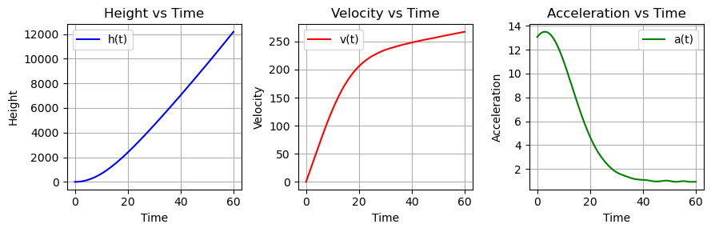

```python
import numpy as np
import sympy as sp
from sympy import Symbol as Symb
from sympy import Function as Func
from scipy.integrate import solve_ivp,simpson
from scipy.interpolate import interp1d
import matplotlib.pyplot as plt

# 定义符号变量
t = Symb('t')
v = Func('v')
v = v(t)

eq=sp.Eq(v.diff(t),((32000-0.4*v**2)/(1400-18*t))-9.8)

v_prime = sp.lambdify((t, v), eq.rhs, 'numpy')
t_span = (0, 60)
initial_conditions = [0]
sol = solve_ivp(v_prime, t_span, initial_conditions, method='RK45', t_eval=np.linspace(0, 60, 600))
v_at_t_60 = sol.y[0][-1]
print("t = 60 时对应的 v 值为:", v_at_t_60)
a_at_t_60 = v_prime(60, v_at_t_60)
print("t = 60 时对应的 a 值为:", a_at_t_60)
h = simpson(sol.y[0], sol.t)
print("t = 0 到 t = 60 内 v 的积分为:", h)

fig, axs = plt.subplots(1, 3, figsize=(9, 3))

# 绘制 h(t) 的图像
h_values = np.array([simpson(sol.y[0][:i], sol.t[:i]) for i in range(1, len(sol.t)+1)])
axs[0].plot(sol.t, h_values, label="h(t)", color="blue")
axs[0].set_xlabel("Time")
axs[0].set_ylabel("Height")
axs[0].set_title("Height vs Time")
axs[0].grid(True)
axs[0].legend()

# 绘制 v(t) 的图像
axs[1].plot(sol.t, sol.y[0], label="v(t)", color="red")
axs[1].set_xlabel("Time")
axs[1].set_ylabel("Velocity")
axs[1].set_title("Velocity vs Time")
axs[1].grid(True)
axs[1].legend()

# 绘制 a(t) 的图像
a_values = v_prime(sol.t, sol.y[0])
axs[2].plot(sol.t, a_values, label="a(t)", color="green")
axs[2].set_xlabel("Time")
axs[2].set_ylabel("Acceleration")
axs[2].set_title("Acceleration vs Time")
axs[2].grid(True)
axs[2].legend()

plt.tight_layout()  # 自动调整子图布局，以防止重叠
plt.show()
```

```
v = 0 时对应的 t 值为: 71.32548564034924
v = 0 时对应的最大高度为: 13116.15694325809
v=0 时加速度为 -9.8
```

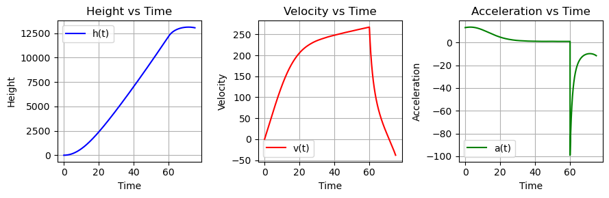

```python
eq2 = sp.Eq(v.diff(t), (- 0.4 * v**2) / (320) - 9.8)

v_prime = sp.lambdify((t, v), eq2.rhs, "numpy")
t_span = (60, 75)
initial_conditions = [v_at_t_60]
sol2 = solve_ivp(
    v_prime, t_span, initial_conditions, method="RK45", t_eval=np.linspace(60, 75, 400)
)

# 找到v=0时的t
f = interp1d(sol2.y[0], sol2.t)
t_at_v_0 = f(0)
print("v = 0 时对应的 t 值为:", t_at_v_0)
# t=t_at_v_0时的高度
v_interp = interp1d(sol2.t, sol2.y[0])
t_when_v_pos = np.linspace(60, t_at_v_0, 100)
h_max=simpson(v_interp(t_when_v_pos),t_when_v_pos)+h
print("v = 0 时对应的最大高度为:", h_max)
print("v=0 时加速度为",v_prime(t_at_v_0,0))

fig, axs = plt.subplots(1, 3, figsize=(9, 3))


t_combined = np.concatenate((sol.t, sol2.t))
# 绘制 h(t) 的图像
h_values = np.array(
    [simpson(sol.y[0][:i], sol.t[:i]) for i in range(1, len(sol.t) + 1)]
)
h_values2 = np.array(
    [simpson(sol2.y[0][:i], sol2.t[:i]) + h for i in range(1, len(sol2.t) + 1)]
)
h_values_combined = np.concatenate((h_values, h_values2))
axs[0].plot(t_combined, h_values_combined, label="h(t)", color="blue")
axs[0].set_xlabel("Time")
axs[0].set_ylabel("Height")
axs[0].set_title("Height vs Time")
axs[0].grid(True)
axs[0].legend()

# 绘制 v(t) 的图像
v_values_combined = np.concatenate((sol.y[0], sol2.y[0]))
axs[1].plot(t_combined, v_values_combined, label="v(t)", color="red")
axs[1].set_xlabel("Time")
axs[1].set_ylabel("Velocity")
axs[1].set_title("Velocity vs Time")
axs[1].grid(True)
axs[1].legend()

# 绘制 a(t) 的图像
a_values2 = v_prime(sol2.t, sol2.y[0])
a_values_combined = np.concatenate((a_values, a_values2))
axs[2].plot(t_combined, a_values_combined, label="a(t)", color="green")
axs[2].set_xlabel("Time")
axs[2].set_ylabel("Acceleration")
axs[2].set_title("Acceleration vs Time")
axs[2].grid(True)
axs[2].legend()

plt.tight_layout()  # 自动调整子图布局，以防止重叠
plt.show()
```

## 第5题 放射性废物处理

### 问题分析与模型建立

- 水桶重量$G=527.436lbf=2344.6N$,水桶质量$m=G/g=239.2449kg$
- 浮力$F=2,090.7352N$,
- 阻力$\mathcal{f}=kv$,其中$k=0.081lbf s/ft=1.1813kg/m$
- 重力加速度取$g=9.8m/s^2$
- 水桶可以承受的最大速度$v_{max}=12.192m/s$
- 以水面入水点为原点，竖直向下为正方向，可以画出受力图。水桶受到重力，浮力，阻力三个力，其中浮力与阻力方向向上，重力方向向下。 综上可以列出v-t的微分方程 $$ \left\{ \begin{aligned} &\frac{dv}{dt} = \frac {-F-kv+mg}{m}\\ &v(0)=0\\ \end{aligned} \right. $$ 这就是解决这个问题的微分方程，可以通过欧拉方法或龙格库塔方法求解得到v(t)。然后判断v(t)是否在水桶达到海底之前达到最大速度，如果达到则会发生破裂，否则不会发生破裂，从而解决这个问题。

### 代码实现与结果

上面的微分方程容易用解析法解出。如下面代码结果给出了v-t的解析式。

```python
from sympy import Function, Symbol, dsolve, Eq, exp

# 定义未知函数
t = Symbol("t")
a,b=Symbol("a"),Symbol("b")
v = Function("v")(t)

# 定义微分方程
diff_eq = Eq(v.diff(t), a*v + b)

# 求解微分方程
ics={v.subs(t,0):0}
solution = dsolve(diff_eq, ics=ics)
solution
```

$\displaystyle v{\left(t \right)} = \frac{b e^{a t}}{a} - \frac{b}{a}$

其中$a=-k/m=-4.9376183e^{-3}$,$b=g-F/m=1.0611085$ v对t积分,得到h的解析解为 $$ h(t) = \frac{be^{at}}{a^2}-\frac{bt}{a}-\frac{b}{a^2},(t=0时h=0) $$ 由于v(t)>0恒成立，所以h(t)是单调递增的，可以考虑用插值法求出h=H=91.44m时的t，然后判断此时v是否小于$v_{max}$，从而判断水桶是否会破裂。

```
v(t) =  b*(exp(a*t) - 1)/a
```

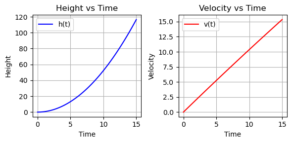

```python
# 定义函数
h=Function("h")(t)
v=Function("v")(t)

h_expr=(b*exp(a*t))/(a**2) - (b*t)/a - b/(a**2)
v_expr = h_expr.diff(t)
print("v(t) = ", v_expr.simplify())
params = {a: -4.9376183e-3, b: 1.0611085}
h_expr_with_values = h_expr.subs(params)
v_expr_with_values = v_expr.subs(params)
h_func = sp.lambdify(t, h_expr_with_values, "numpy")
v_func = sp.lambdify(t, v_expr_with_values, "numpy")
t_values = np.linspace(0, 15, 100)
h_values = h_func(t_values)
v_values = v_func(t_values)
fig, axs = plt.subplots(1, 2, figsize=(6, 3))
axs[0].plot(t_values, h_values, label="h(t)", color="blue")
axs[0].set_xlabel("Time")
axs[0].set_ylabel("Height")
axs[0].set_title("Height vs Time")
axs[0].grid(True)
axs[0].legend()
axs[1].plot(t_values, v_values, label="v(t)", color="red")
axs[1].set_xlabel("Time")
axs[1].set_ylabel("Velocity")
axs[1].set_title("Velocity vs Time")
axs[1].grid(True)
axs[1].legend()
plt.tight_layout()
plt.show()
```

观察图像可以看到大概在$t \in [10,15]$时水桶到达海底，考虑用插值法求出此时的t

```python
from scipy.interpolate import interp1d

t_values = np.linspace(0, 15, 100)
h_values = h_func(t_values)
H=91.44
v_values = v_func(t_values)
t_of_h=interp1d(h_values,t_values)
t_max=t_of_h(H)
print("h=91.44时的t值为",t_max)
```

```
h=91.44时的t值为 13.271315054137077
```

```python
v_of_t=interp1d(t_values,v_values)
v_max=v_of_t(t_max)
print("h=91.44时的v值为",v_max)
```

```
h=91.44时的v值为 13.630809392770804
```

所以我们用解析法求出的结果是$t=13.27s$时水桶到达海底，速度为$13.6m/s$，大于$v_{max}$，所以水桶会破裂。

### 数值法

下面我们用数值法求解这个问题

```python
rhs_expr=a*v+b
rhs_expr_with_values =rhs_expr.subs(params)
t_span=(0,15)
initial_conditions=[0]
v_prime = sp.lambdify((t, v), rhs_expr_with_values, "numpy")
from scipy.integrate import solve_ivp
sol = solve_ivp(v_prime, t_span, initial_conditions, method="RK45", t_eval=np.linspace(0, 15, 100))
h_values = np.array(
    [simpson(sol.y[0][:i], sol.t[:i]) for i in range(1, len(sol.t) + 1)]
)
t_of_h=interp1d(h_values,sol.t)
t_max=t_of_h(H)
print("h=91.44时的t值为",t_max)
```

```
h=91.44时的t值为 13.271315046951976
```

可以看到，用数值解法求出的结果精度已经超过了本题的要求(两位小数)，实际上二者相当接近了。下面我们用数值法求出水桶到达海底的速度，然后判断水桶是否会破裂。

```python
v_of_t=interp1d(sol.t,sol.y[0])
v_max=v_of_t(t_max)
print("h=91.44时的v值为",v_max)
```

```
h=91.44时的v值为 13.630809384884
```

### 结果分析

- 解析解得到的结果是$v=13.63m/s$，数值解得到的结果是$v=13.63m/s$，两者相当接近，说明数值解法的正确性。

### 结论

两种方法求解微分方程给出的结果都大于$v_{max}$，所以水桶会破裂，所以生态学家赢得了官司。

### 意义

通过这个问题，我们可以了解到微分方程的求解方法，以及如何通过微分方程模型解决实际问题。

## 第9题 种群竞争模型

### 问题分析与模型建立

竞争模型由题目已经给出。题目主要是探讨不同参数的影响

```python
from scipy.integrate import solve_ivp
from sympy import Function, Symbol,exp

# 定义符号变量
t,r_1,r_2,n_1,n_2,s_1,s_2=Symbol("t"),Symbol("r_1"),Symbol("r_2"),Symbol("n_1"),Symbol("n_2"),Symbol("s_1"),Symbol("s_2")
x=Function("x")(t)
y=Function("y")(t)

f1_expr = r_1*x*(1-x/n_1-s_1*y/n_2)
f2_expr = r_2*y*(1-s_2*x/n_1-y/n_2)


print("f1(x,y) = ", f1_expr)
print("f2(x,y) = ", f2_expr)
```

```
f1(x,y) =  r_1*(1 - s_1*y(t)/n_2 - x(t)/n_1)*x(t)
f2(x,y) =  r_2*(1 - y(t)/n_2 - s_2*x(t)/n_1)*y(t)
```

### 算法设计

- 写出微分方程的表达式
- 代入参数，用欧拉方法和龙格库塔方法求解微分方程
- 画出种群随时间的变化图像
- 分析不同参数对种群的影响
- 画出相图，分析相图的稳定性

### 代码实现与结果

#### 第一问

将下列参数代入微分方程

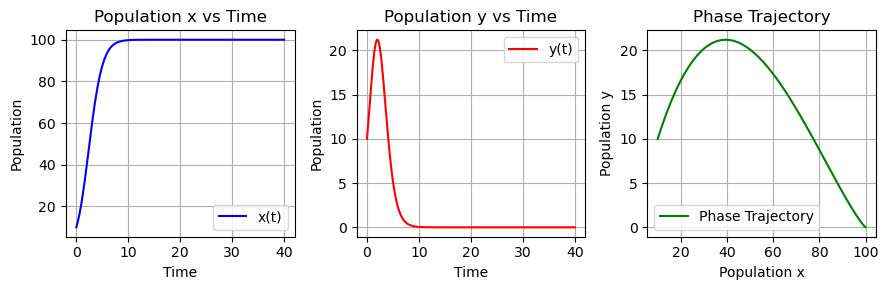

```python
params = {r_1: 1, r_2: 1, n_1: 100, n_2: 100, s_1: 0.5, s_2: 2}

def show_figs_with_params(params, initial_conditions=[10, 10]):
    f1_lambda = sp.lambdify((t,x, y), f1_expr.subs(params), "numpy")
    f2_lambda = sp.lambdify((t,x, y), f2_expr.subs(params), "numpy")

    # 定义常微分方程组
    def ode_system(t, x_list):
        x, y = x_list
        dxdt = f1_lambda(t, x, y)
        dydt = f2_lambda(t, x, y)
        return [dxdt, dydt]

    # 设置初始条件和求解时间范围
    initial_conditions = initial_conditions
    t_span = (0, 40)
    sol = solve_ivp(
        ode_system,
        t_span,
        initial_conditions,
        method="RK45",
        t_eval=np.linspace(0, 40, 400),
    )

    # 获取解
    t_values = sol.t
    x_values = sol.y[0]
    y_values = sol.y[1]

    # 绘制 x(t) 和 y(t) 的图像以及相轨迹
    fig, axs = plt.subplots(1, 3, figsize=(9, 3))
    axs[0].plot(t_values, x_values, label="x(t)", color="blue")
    axs[0].set_xlabel("Time")
    axs[0].set_ylabel("Population")
    axs[0].set_title("Population x vs Time")
    axs[0].grid(True)
    axs[0].legend()
    axs[1].plot(t_values, y_values, label="y(t)", color="red")
    axs[1].set_xlabel("Time")
    axs[1].set_ylabel("Population")
    axs[1].set_title("Population y vs Time")
    axs[1].grid(True)
    axs[1].legend()

    axs[2].plot(x_values, y_values, label="Phase Trajectory", color="green")
    axs[2].set_xlabel("Population x")
    axs[2].set_ylabel("Population y")
    axs[2].set_title("Phase Trajectory")
    axs[2].grid(True)
    axs[2].legend()
    plt.tight_layout()
    plt.show()


show_figs_with_params(params)
```

从图像可以看出时间充分大后，x种群数目稳定在100（最大容量），y种群数目趋于0。

#### 第二问

```
参数组1: {r_1: 1, r_2: 1, n_1: 100, n_2: 100, s_1: 0.5, s_2: 2}
```

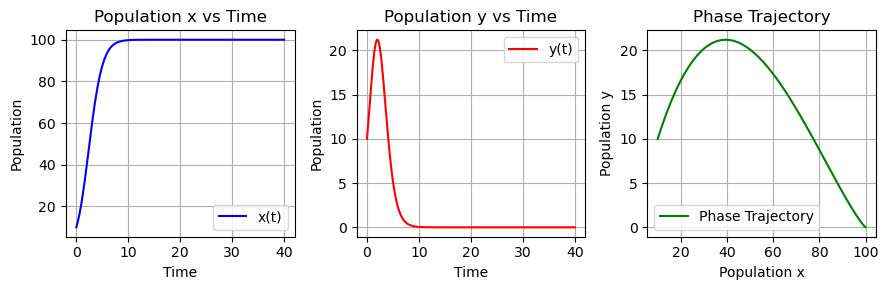

```
参数组2: {r_1: 1, r_2: 1, n_1: 100, n_2: 400, s_1: 0.5, s_2: 2}
```

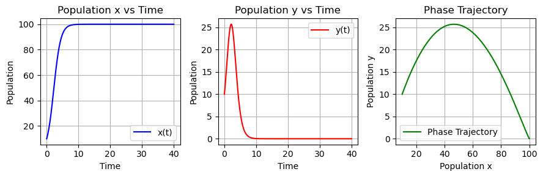

```
参数组3: {r_1: 1, r_2: 4, n_1: 100, n_2: 100, s_1: 0.5, s_2: 2}
```

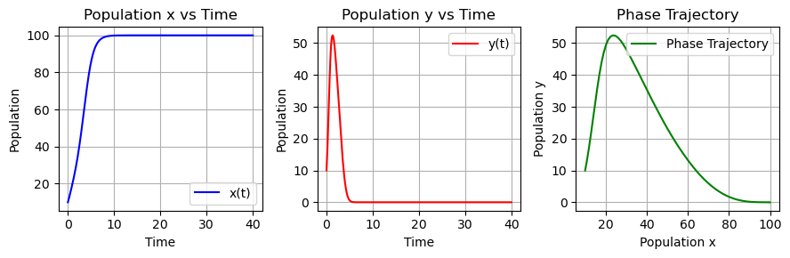

```
参数组4: {r_1: 1, r_2: 1, n_1: 100, n_2: 100, s_1: 0.5, s_2: 2}
```

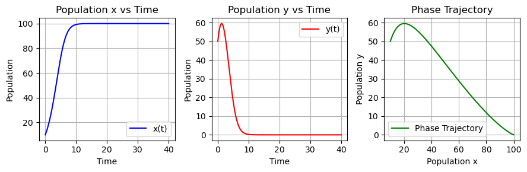

```
参数组5: {r_1: 1, r_2: 1, n_1: 400, n_2: 100, s_1: 1.5, s_2: 0.7}
```

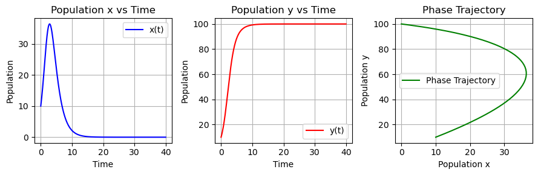

```python
params_1 = {r_1: 1, r_2: 1, n_1: 100, n_2: 100, s_1: 0.5, s_2: 2}
params_2 = {r_1: 1, r_2: 1, n_1: 100, n_2: 400, s_1: 0.5, s_2: 2}
params_3 = {r_1: 1, r_2: 4, n_1: 100, n_2: 100, s_1: 0.5, s_2: 2}
params_4 = {r_1: 1, r_2: 1, n_1: 100, n_2: 100, s_1: 0.5, s_2: 2}

params_5 = {r_1: 1, r_2: 1, n_1: 400, n_2: 100, s_1: 1.5, s_2: 0.7}

print("参数组1:",params_1)
show_figs_with_params(params_1)
print("参数组2:",params_2)
show_figs_with_params(params_2)
print("参数组3:",params_3)
show_figs_with_params(params_3)
print("参数组4:",params_4)
show_figs_with_params(params_4,['10','50'])
print("参数组5:", params_5)
show_figs_with_params(params_5)
```

可以看到，前四组的结果和第一问的结果类似，第五组的结果则大致和前面所有组相反。

### 第三问

使用第三问的参数

```
参数组6: {r_1: 1, r_2: 1, n_1: 100, n_2: 100, s_1: 0.8, s_2: 0.7}
```

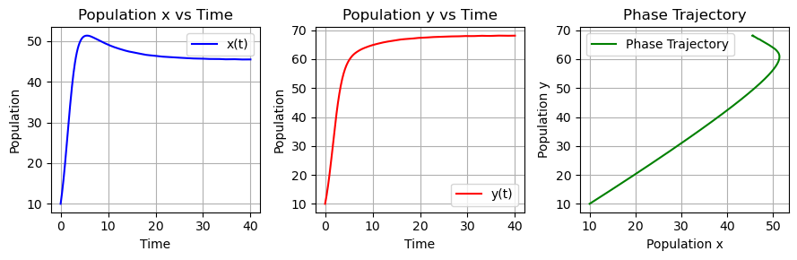

```
参数组6:初始条件为[50,10]
```

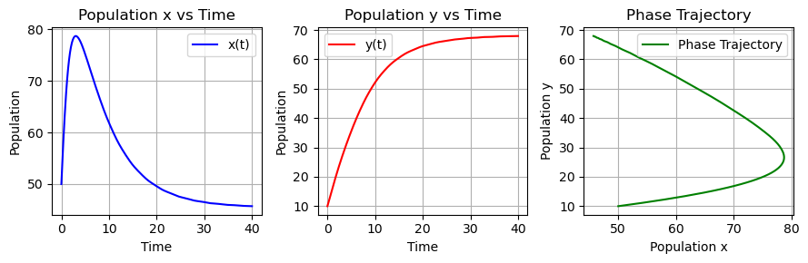

```
参数组6:初始条件为[10,50]
```

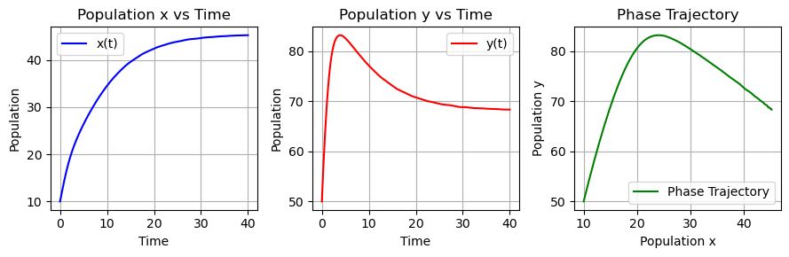

```
参数组7: {r_1: 1, r_2: 1, n_1: 100, n_2: 100, s_1: 1.5, s_2: 1.7}
```

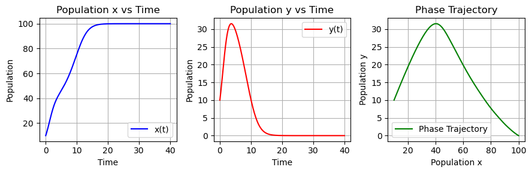

```
参数组8: {r_1: 2, r_2: 2, n_1: 100, n_2: 100, s_1: 1.5, s_2: 1.7}
```

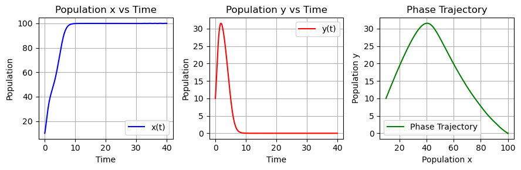

```
参数组8:初始条件为[10,50]
```

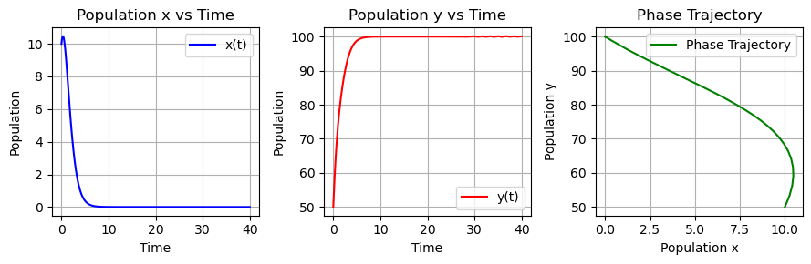

```python
params_6 = {r_1: 1, r_2: 1, n_1: 100, n_2: 100, s_1: 0.8, s_2: 0.7}
params_7 = {r_1: 1, r_2: 1, n_1: 100, n_2: 100, s_1: 1.5, s_2: 1.7}

print("参数组6:",params_6)
show_figs_with_params(params_6)

print("参数组6:初始条件为[50,10]")
show_figs_with_params(params_6, [50, 10])

print("参数组6:初始条件为[10,50]")
show_figs_with_params(params_6, [10, 50])

print("参数组7:",params_7)
show_figs_with_params(params_7)

params_8 = {r_1: 2, r_2: 2, n_1: 100, n_2: 100, s_1: 1.5, s_2: 1.7}
print("参数组8:", params_8)
show_figs_with_params(params_8)

print("参数组8:初始条件为[10,50]")
show_figs_with_params(params_8, [10, 50])
```

### 现象

- 第二问的图像中可以看出，只要保证了$s_1,s_2$不变，即$s_1<1,s_2>1$，种群最终都会稳定在100，0。
- 如果$s_1>1,s_2<1$，则种群最终会稳定在0，100。
- 在尝试的结果中，参数$s_1,s_2$的变化对种群的影响是最大的，其他参数的变化对种群的影响较小。
- 在尝试的参数中，两个种群开始时种群数目总是先增加
- 第三问中，当$s_1=0.8,s_2=0.7$时，随时间二者达到平衡，并且种群数均不为0，但是y种群数目更多
- 改变初始种群个数，两个种群均没有完全驱逐另一个种群，而且在其他参数不变的情况下，最终结果几乎不变
- 而当二者均大于1时，对于不同初始条件，两个种群都有可能得胜（即最终完全驱逐另一个种群）

### 结论

通过对种群竞争模型的分析，我们可以看到不同参数对种群的影响，这对于生态学研究是很有意义的。 发现在种群竞争模型中，最关键的参数是$s_1,s_2$，它们决定了种群最终的竞争结果。根据实验结果可以列表整理如下

- 当$s_1,s_2<1$时，两个种群都会达到平衡，二者可以共存
- 当$s_1,s_2>1$时，两个种群都有可能完全驱逐另一个种群
- 当$s_1<1,s_2>1$时，x种群会达到最大容量，y种群会被驱逐
- 当$s_1>1,s_2<1$时，y种群会达到最大容量，x种群会被驱逐

## 实验心得

- 数值解法常常需要对解的大致范围做一个估计，所以往往是先用图像等方法估计一个解的范围，然后再用数值解法求解。这样可以提高数值解法的效率。
- 插值法是一个很有用的方法，可以用来求解一些特殊的问题，比如求解微分方程的解析解，求解某个函数的零点等。